# Regression

Kenneth L Osborne

October 12, 2018

```r
suppressPackageStartupMessages(library(magrittr))
suppressPackageStartupMessages(library(tidyverse))
suppressPackageStartupMessages(library(lubridate))
suppressPackageStartupMessages(library(caret))
suppressPackageStartupMessages(library(caretEnsemble))
suppressPackageStartupMessages(library(mlbench))
suppressPackageStartupMessages(library(ROCR))
suppressPackageStartupMessages(library(pROC))
suppressPackageStartupMessages(library(psych))
```

# Regression

Regression

Now, you must use any combination of Azure Machine Learning, R or Python to create a regression model that predicts the average monthly spend of a new customers.

1.Use the Adventure Works Cycles customer data you worked with in challenge 1 and 2 to create a regression model that predicts a customer’s average monthly spend. The model should predict average monthly spend for new customers for whom no information about average monthly spend or previous bike purchases is available.

2.Download the test data. This is the same test data that you have used in classification challenge. This data includes customer features but does not include bike purchasing or average monthly spend values.

3.Use your model to predict on the corresponding test dataset. Don’t forget to apply what you’ve learned throughout this course. Go to the next page to check how well your prediction against the actual result.

## Data Prep

Loading the csv files into dataframes in R goes as follows. Note that the `customerData` dataset has been cleaned and explored in the previous section of the data challenge.

```r
customerData <- read.csv("../customerData.csv", stringsAsFactors = FALSE)
```

This is the same data that was cleaned with the data exploration.

### Label Imbalance

With any label data, it’s useful to know the label balance. For `BikeBuyer`, our current label of interest, we want to know how many people did vs did not buy bikes. We’ll transform the label data to make it a bit easier to read, and then check the label balance. We’ll do the same for the `HomeOwnerFlag` variable while we’re at it.

```r
customerData %<>%
  mutate(
    BikeBuyer = ifelse(BikeBuyer == 1, "yes", "no") %>% as.factor(),
    HomeOwnerFlag = ifelse(HomeOwnerFlag == 1, "yes", "no") %>% as.factor()
  )
table(customerData$BikeBuyer)
```

```
##
##    no   yes
## 10949  5455
```

```r
ratio <- table(customerData$BikeBuyer)[1]/table(customerData$BikeBuyer)[2]
ratio
```

```
##       no
## 2.007149
```

As we can see, the ratio of customers that didn’t buy bikes to those who did is 2:1. We’ll take that into consideration later.

### Preprocessing

Next we’ll go through the data and sort out which of our variables we’ll include in our model. We’ll also scale and center our numerical data.

```r
colnames(customerData)
```

```
##  [1] "CustomerID"           "Title"                "FirstName"
##  [4] "MiddleName"           "LastName"             "Suffix"
##  [7] "AddressLine1"         "AddressLine2"         "City"
## [10] "StateProvinceName"    "CountryRegionName"    "PostalCode"
## [13] "PhoneNumber"          "BirthDate"            "Education"
## [16] "Occupation"           "Gender"               "MaritalStatus"
## [19] "HomeOwnerFlag"        "NumberCarsOwned"      "NumberChildrenAtHome"
## [22] "TotalChildren"        "YearlyIncome"         "BikeBuyer"
## [25] "AveMonthSpend"        "Age"                  "AgeCategory"
## [28] "CarCategory"          "ChildrenHome"
```

Variables 1-13 just give basic identification information about the customers, and are not likely to correlate well with any predictive information. We’ll drop them.

The `BirthDate` variable is likely just a poor man’s version of the `Age` or `Age Category` variable, as it is unlikely that bike buyers all have the commonalities in birth month or date.

On the other hand, the created variables of `CarCategory` and `ChildrenHome` did seem to split the data well. We’ll keep these variables, and transform the `testing` data set to include them.

Finally, for this challenge, we don’t have access to the `BikeBuyer` variable, and so we drop it for the time being.

```r
customerData <- customerData %>% select(-(1:13),-BirthDate, -BikeBuyer) %>% mutate(logSpend = log10(AveMonthSpend))
customerData %>% head(10) %>% as.tibble()
```

```
## # A tibble: 10 x 15
##    Education Occupation Gender MaritalStatus HomeOwnerFlag NumberCarsOwned
##  * <chr>     <chr>      <chr>  <chr>         <fct>                   <int>
##  1 "Bachelo~ Professio~ M      M             yes                         0
##  2 "Bachelo~ Professio~ M      S             no                          1
##  3 "Bachelo~ Professio~ M      M             yes                         1
##  4 "Bachelo~ Professio~ F      S             no                          1
##  5 "Bachelo~ Professio~ F      S             yes                         4
##  6 "Bachelo~ Professio~ M      S             yes                         1
##  7 "Bachelo~ Professio~ F      S             yes                         1
##  8 "Bachelo~ Professio~ M      M             yes                         2
##  9 "Bachelo~ Professio~ F      S             yes                         3
## 10 "Bachelo~ Professio~ M      S             no                          1
## # ... with 9 more variables: NumberChildrenAtHome <int>,
## #   TotalChildren <int>, YearlyIncome <int>, AveMonthSpend <int>,
## #   Age <dbl>, AgeCategory <chr>, CarCategory <chr>, ChildrenHome <lgl>,
## #   logSpend <dbl>
```

We’ll scale and center the numeric variables.

```r
num_cols <- sapply(customerData,class) %in% c("integer","numeric") %>%
  colnames(customerData)[.]

num_cols
```

```
## [1] "NumberCarsOwned"      "NumberChildrenAtHome" "TotalChildren"
## [4] "YearlyIncome"         "AveMonthSpend"        "Age"
## [7] "logSpend"
```

We see that despite being numeric, the first three variables, `NumberCarsOwned, NumberChildrenAtHome, TotalChildren` are better classified as categorical variables than numerical. We correct this.

```r
fact_cols <- num_cols[1:3]
customerData[,fact_cols] %<>% sapply(., as.factor)
num_cols %<>% .[-(1:3)] #leave out the first three variables, they're more categorical
```

Then we check that our numerical data are well behaved.

```r
sapply(customerData[,num_cols], skew)
```

```
##  YearlyIncome AveMonthSpend           Age      logSpend
##     0.3567476     1.3130913     0.5707204     0.4275497
```

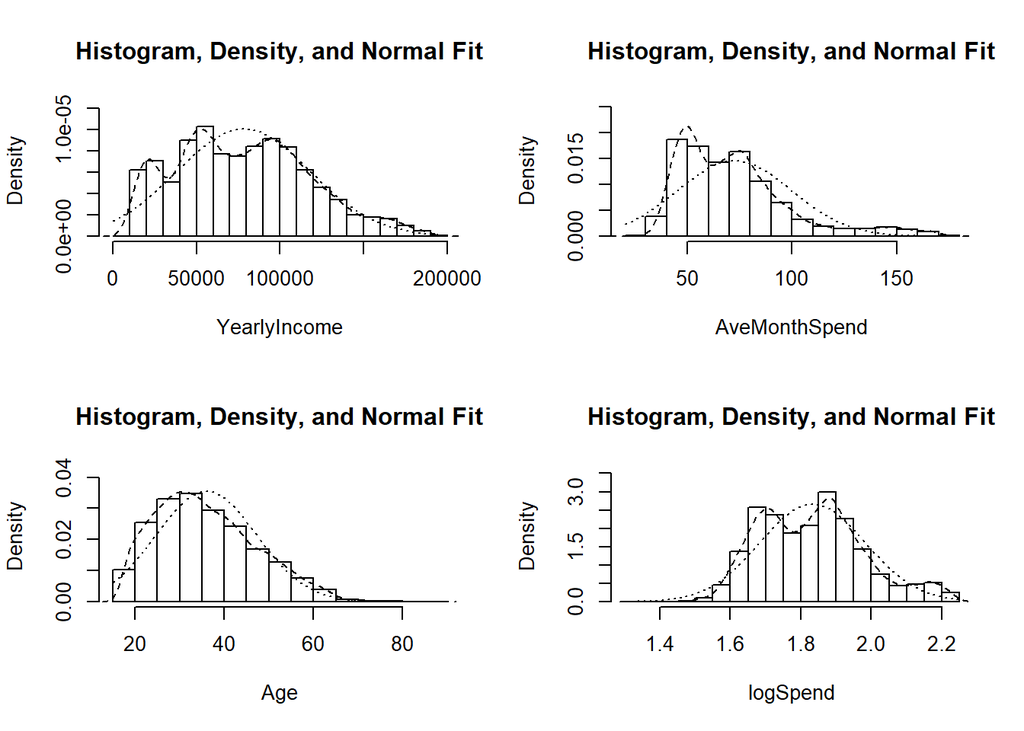

```r
multi.hist(customerData[,num_cols])
```

The `AveMonthSpend` plot is a little right-skewed, so we’ll use the `logSpend` instead, which is much more normal.

```r
preProcValues <- preProcess(customerData[,num_cols], method = c("center", "scale"))

ppCustomerData <- customerData
ppCustomerData[,num_cols] <-  predict(preProcValues, customerData[,num_cols])
head(ppCustomerData[,num_cols])
```

```
##   YearlyIncome AveMonthSpend        Age   logSpend
## 1    1.5056572     0.6090592 -0.3750560  0.7797568
## 2    0.5792163     1.6358316 -0.2949509  1.5737933
## 3    0.3477445     1.8558542 -0.3168641  1.7189657
## 4    0.2154210    -0.8210879 -0.5401357 -0.8940611
## 5    0.3685357     0.8290819 -0.5827448  0.9691398
## 6    0.6310181     0.2056844 -0.3151598  0.3967919
```

Before continuing we’ll convert the remaining character features into factors.

```r
char_cols <- ppCustomerData %>% sapply(class) %in% "character"
ppCustomerData[,char_cols] %<>% lapply(., as.factor)

fact_cols <- ppCustomerData %>% sapply(class) %in% "factor"
ppCustomerData %>% head() %>% as.tibble
```

```
## # A tibble: 6 x 15
##   Education Occupation Gender MaritalStatus HomeOwnerFlag NumberCarsOwned
## * <fct>     <fct>      <fct>  <fct>         <fct>         <fct>
## 1 "Bachelo~ Professio~ M      M             yes           0
## 2 "Bachelo~ Professio~ M      S             no            1
## 3 "Bachelo~ Professio~ M      M             yes           1
## 4 "Bachelo~ Professio~ F      S             no            1
## 5 "Bachelo~ Professio~ F      S             yes           4
## 6 "Bachelo~ Professio~ M      S             yes           1
## # ... with 9 more variables: NumberChildrenAtHome <fct>,
## #   TotalChildren <fct>, YearlyIncome <dbl>, AveMonthSpend <dbl>,
## #   Age <dbl>, AgeCategory <fct>, CarCategory <fct>, ChildrenHome <lgl>,
## #   logSpend <dbl>
```

Other analyses are done in the classification challenge to show that none of the features is near zero variance. As such we’ll continue to the analysis.

## Regression Model

```r
partition  <- createDataPartition(ppCustomerData$logSpend,
                                  times = 1, p = 0.7, list = FALSE)
training   <- ppCustomerData[ partition,] # Create the training sample
validation <- ppCustomerData[-partition,] # Create the test sample

trainingLabel   <- customerData[ partition,] %>% select(AveMonthSpend)
validationLabel <- customerData[-partition,] %>% select(AveMonthSpend)

cat(
  "Dim Training:  ", dim(training),
  "\nDim Validation: ", dim(validation)
)
```

```
## Dim Training:   11486 15
## Dim Validation:  4918 15
```

Next we define and fit the linear regression

```r
lin_mod <- lm(logSpend ~ ., data = training %>% select(-AveMonthSpend))
summary(lin_mod)
```

```
##
## Call:
## lm(formula = logSpend ~ ., data = training %>% select(-AveMonthSpend))
##
## Residuals:
##      Min       1Q   Median       3Q      Max
## -1.47756 -0.09098  0.00705  0.09865  0.71626
##
## Coefficients: (3 not defined because of singularities)
##                                Estimate Std. Error t value Pr(>|t|)
## (Intercept)                  -0.9652831  0.0101594 -95.013  < 2e-16 ***
## EducationGraduate Degree     -0.0227368  0.0054045  -4.207 2.61e-05 ***
## EducationHigh School         -0.0276268  0.0056136  -4.921 8.71e-07 ***
## EducationPartial College     -0.0019936  0.0048886  -0.408 0.683424
## EducationPartial High School -0.0574944  0.0077689  -7.401 1.45e-13 ***
## OccupationManagement          0.0171262  0.0091864   1.864 0.062304 .
## OccupationManual             -0.1071206  0.0063628 -16.835  < 2e-16 ***
## OccupationProfessional        0.0559162  0.0066560   8.401  < 2e-16 ***
## OccupationSkilled Manual      0.0381509  0.0054448   7.007 2.57e-12 ***
## GenderM                       1.1599903  0.0032329 358.804  < 2e-16 ***
## MaritalStatusS               -0.2333597  0.0033358 -69.957  < 2e-16 ***
## HomeOwnerFlagyes              0.0123844  0.0035260   3.512 0.000446 ***
## NumberCarsOwned1             -0.0004516  0.0052174  -0.087 0.931028
## NumberCarsOwned2              0.0059574  0.0057797   1.031 0.302686
## NumberCarsOwned3             -0.0066816  0.0077297  -0.864 0.387385
## NumberCarsOwned4             -0.0379817  0.0088415  -4.296 1.75e-05 ***
## NumberChildrenAtHome1         0.4533020  0.0055785  81.259  < 2e-16 ***
## NumberChildrenAtHome2         0.8115985  0.0069659 116.510  < 2e-16 ***
## NumberChildrenAtHome3         1.1502440  0.0082834 138.861  < 2e-16 ***
## NumberChildrenAtHome4         1.4614760  0.0088544 165.056  < 2e-16 ***
## NumberChildrenAtHome5         1.7313104  0.0110657 156.457  < 2e-16 ***
## TotalChildren1               -0.0016275  0.0062856  -0.259 0.795702
## TotalChildren2                0.0173520  0.0071672   2.421 0.015493 *
## TotalChildren3                0.0355808  0.0079731   4.463 8.17e-06 ***
## TotalChildren4                0.0267200  0.0082630   3.234 0.001225 **
## TotalChildren5                0.0491667  0.0095345   5.157 2.56e-07 ***
## YearlyIncome                  0.2648294  0.0033004  80.241  < 2e-16 ***
## Age                          -0.0556636  0.0043590 -12.770  < 2e-16 ***
## AgeCategory(25,45]            0.1364997  0.0066765  20.445  < 2e-16 ***
## AgeCategory(45,55]            0.0658846  0.0114776   5.740 9.69e-09 ***
## AgeCategory(55,88.4]         -0.1450690  0.0157572  -9.207  < 2e-16 ***
## CarCategory[1,3)                     NA         NA      NA       NA
## CarCategory[3,5)                     NA         NA      NA       NA
## ChildrenHomeTRUE                     NA         NA      NA       NA
## ---
## Signif. codes:  0 '***' 0.001 '**' 0.01 '*' 0.05 '.' 0.1 ' ' 1
##
## Residual standard error: 0.161 on 11455 degrees of freedom
## Multiple R-squared:  0.9741, Adjusted R-squared:  0.974
## F-statistic: 1.434e+04 on 30 and 11455 DF,  p-value: < 2.2e-16
```

## Model Predictions

We predicted on a log base 10, centered and scaled model. We can undo the centering and scaling. Each point was modified by the formula

xnew = (xold - xavg)/xsd

Where xavg and xsd are the mean and standard deviation our logSpend variable. Then we’ll need to undo the log10, which requires taking 10 to the xold.

### Training Data

We back transform the `logSpend` data, and check how well our model predicted the regular training data.

```r
scaled_training_prediction <- predict(lin_mod, training %>% select(-AveMonthSpend))
xavg <- customerData$logSpend[partition] %>% mean()
xsd <- customerData$logSpend[partition] %>% sd()
uncentered_unscaled_training <- scaled_training_prediction*xsd + xavg

training_prediction <- 10^uncentered_unscaled_training
```

Find RMSE of training set, we compare that with the average and standard deviation.

```r
err_training <- RMSE(training_prediction, trainingLabel[,1])
avg_training <- trainingLabel$AveMonthSpend %>% mean
sd_training <- trainingLabel$AveMonthSpend %>% sd

cat("RMSE:     ", err_training,
    "\nAverage:   ", avg_training,
    "\nDeviation: ", sd_training)
```

```
## RMSE:      3.468527
## Average:    72.37916
## Deviation:  27.2144
```

Despite the large deviations in the dataset, our RMSE was only 3.5, a sign our model did well.

### Validation Data

And then for the true test, our validation data predictions

```r
scaled_validation_prediction <- predict(lin_mod, validation %>% select(-AveMonthSpend))
vavg <- customerData$logSpend[-partition] %>% mean()
vsd <- customerData$logSpend[-partition] %>% sd()
uncentered_unscaled_validation <- scaled_validation_prediction*xsd + xavg

validation_prediction <- 10^uncentered_unscaled_validation

err_testing <- RMSE(validation_prediction, validationLabel[,1])
avg_testing <- validationLabel$AveMonthSpend %>% mean
sd_testing <- validationLabel$AveMonthSpend %>% sd

cat("\nRMSE:     ", err_testing,
    "\nAverage:   ", avg_testing,
    "\nDeviation: ", sd_testing)
```

```
##
## RMSE:      3.512236
## Average:    72.41867
## Deviation:  27.40191
```

## Conclusion

The training and validation sets behave similarly, both giving an RMSE of around 3.5, which is to say showing no significant difference!

With this we can be confident of our results.